# MASZ - Projekt 4 Metryki sieci

Ryszard Szymański

4/4/2020

## Zadanie 1

Do wykonania zadań wykorzystano sieć emaili firmy Enron (źródło: http://networkrepository.com/email-EU.php).

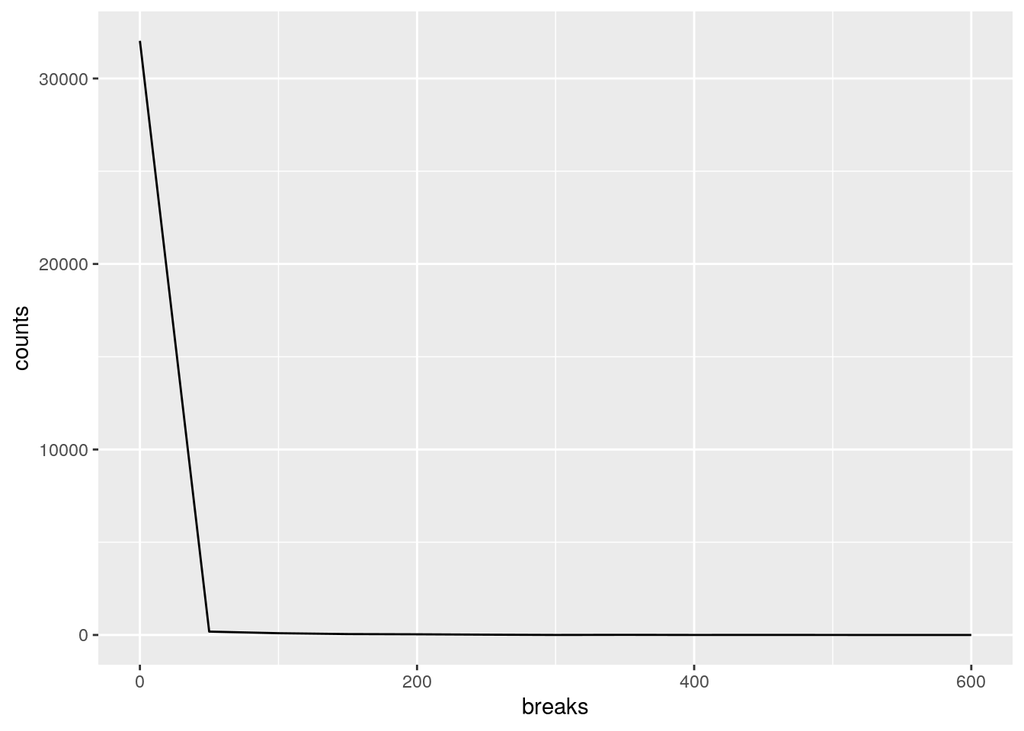

```r
enron <- drake::readd(enron_graph)
hist_vals <- hist(degree(enron), plot = FALSE)

hist_df <- hist2df(hist_vals)

ggplot(hist_df, aes(x = breaks, y = counts)) +
  geom_line()
```

## Zadanie 2

Rysunek jest bardziej czytelny – bliżej mu do linii prostej, której się spodziewamy przy rozkładach potęgowych. Można jednak zauważyć szum bliżej końca narysowanej linii.

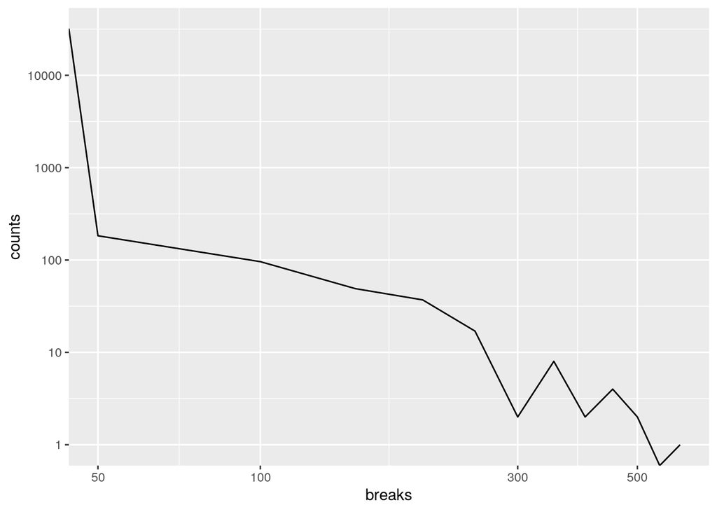

```r
ggplot(hist_df, aes(x = breaks, y = counts)) +
  geom_line() +
  scale_x_log10() +
  scale_y_log10()
```

## Zadanie 3

Zastosowanie logarytmicznego binowania pozwoliło na wygładzenie szumu, które pojawiło się w zadaniu 2

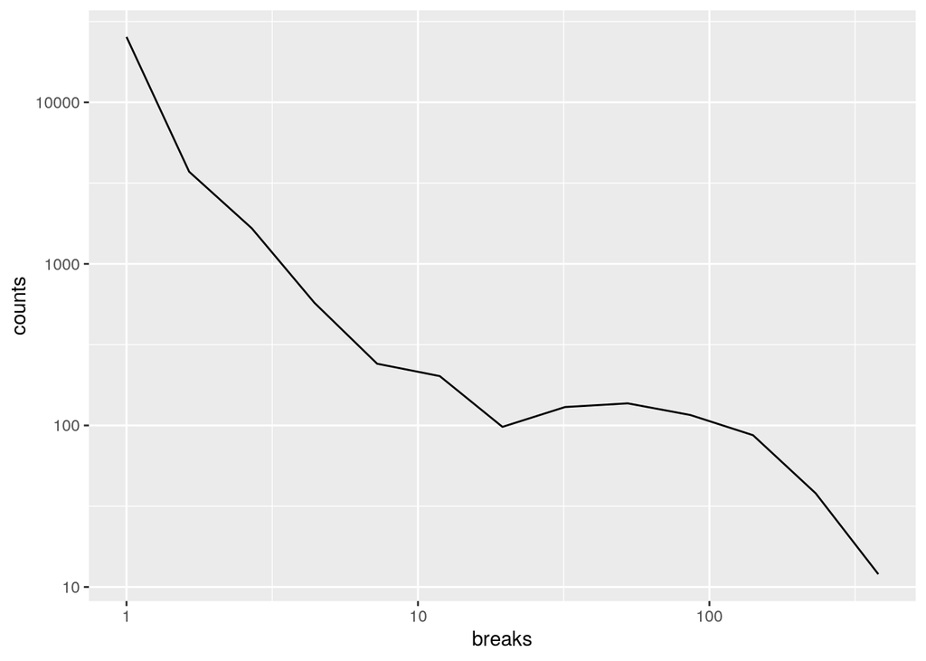

```r
enron_degrees <- degree(enron)
breaks <- exp(seq(log(min(enron_degrees)), log(max(enron_degrees)), length.out = length(hist_vals$breaks)))
hist_vals_log_binned <- hist(enron_degrees, breaks = breaks, probability = TRUE, plot = FALSE)
hist_df <- hist2df(hist_vals_log_binned)

ggplot(hist_df, aes(x = breaks, y = counts)) +
  geom_line() +
  scale_x_log10() +
  scale_y_log10()
```

## Zadanie 4

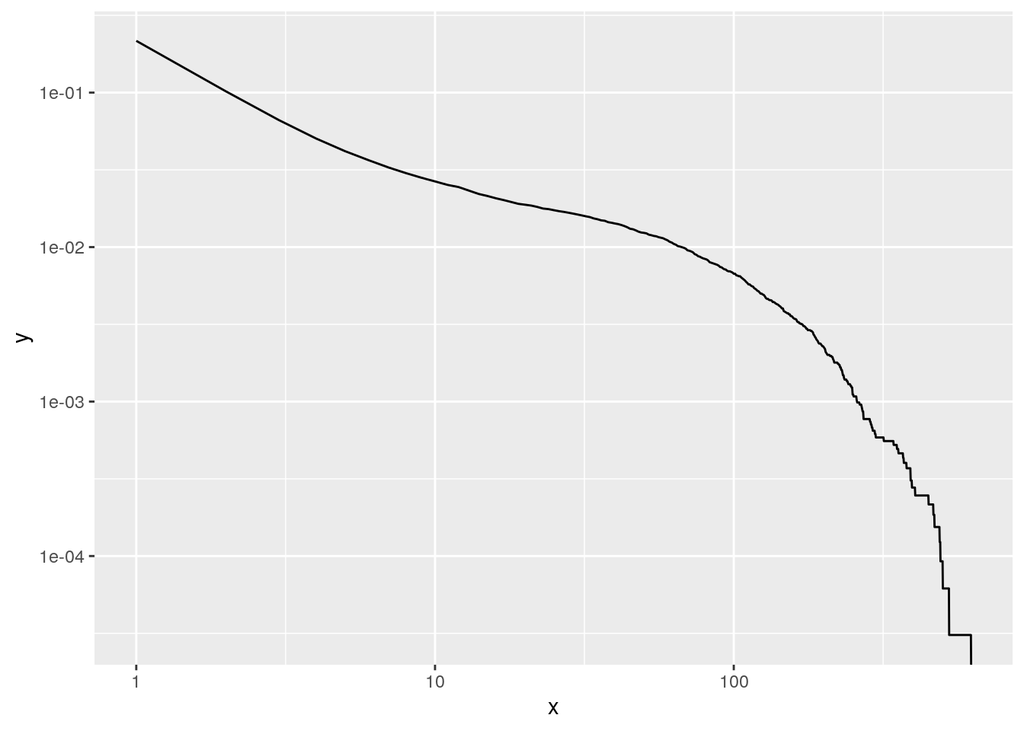

```r
enron_cdf <- ecdf(enron_degrees)
enron_cdf_summary <- summary(enron_cdf)
cdf_min <- enron_cdf_summary[["Min."]]
cdf_max <- enron_cdf_summary[["Max."]]

x <- seq(cdf_min, cdf_max)
survival_fun_values <- 1 - enron_cdf(x)
data.frame(
  x = x,
  y = survival_fun_values
) %>% ggplot(aes(x = x, y = y)) +
  geom_line() +
  scale_x_log10() +
  scale_y_log10()
```

## Zadanie 5

Najbardziej czytelny jest wykres w którym zastosowano jednocześnie skale logarytmiczne oraz logarytmiczne binowanie.

## Zadanie 6

Liniową zależność rozkładów potęgowych w skali podwójnie logarytmicznej można przestawić w następujący sposób:
$$\ln P(x) = -\alpha \ln x + const$$
Można zatem wyznaczyć wartość $\alpha$ za pomocą regresji liniowej.

```r
lm_fit <- lm(log(counts) ~ log(breaks), data = hist_df)
lm_fit_coeffs <- coef(lm_fit)
-lm_fit_coeffs[2]
```

```
## log(breaks)
##   0.9661102
```

## Zadanie 7

Można również skorzystać z estymatora największej wiarygodności $\alpha = 1 + n \left[\sum\limits_{i=1}^{n}\ln\frac{x_i}{x_{min}}\right]$

```r
alpha <- network_exponent(hist_vals_log_binned$counts, xmin = min(hist_vals_log_binned$counts))
alpha
```

```
## $alpha
## [1] 1.322297
##
## $sigma
## [1] 0.08938897
```

## Zadanie 8

```r
xmin <- min(hist_vals_log_binned$counts)
xmin_with_small_error <- 0.9*xmin
alpha_no_xmin <- network_exponent(hist_vals_log_binned$counts, xmin = xmin_with_small_error)
alpha_no_xmin
```

```
## $alpha
## [1] 1.311712
##
## $sigma
## [1] 0.08645325
```

## Zadanie 10

Zakładamy, że sieć jest nieskorelowana i chcemy pokazać, że
$$\langle k_{nn} \rangle (k_i) = \frac{\langle k^2 \rangle}{\langle k \rangle}$$
Wychodzimy od definicji średniego stopnia najbliższego węzłą (dla węzła o stopniu $k_i$) – (użyto definicji z ksiażki Państwa Fronczaków):
$$\langle k_{nn} \rangle (k_i) = \sum\limits_{k_j}k_jP(k_j|k_i)$$
Korzystając wyznaczego wzoru na prawdopobieństwo warunkowe $P(k_i | k_j)$ otrzymujemy
$$\langle k_{nn} \rangle (k_i) = \sum\limits_{k_j}k_j \frac{P(k_j, k_i) \langle k\rangle}{k_i P(k_i)}$$
Następnie korzystając z założenia, że sieć jest nieskorelowana, to $P(k_i, k_j) = P_u(k_i, k_j)$ otrzymujemy (wzór na $P_u$ również pochodzi z książki Państwa Fronczaków):
$$\langle k_{nn} \rangle (k_i) = \sum\limits_{k_j}k_j \frac{k_jk_iP(k_i)P(k_j)}{\langle k \rangle^2} \frac{\langle k\rangle}{k_i P(k_i)} = \sum\limits_{k_j} \frac{k_j^2 P(k_j)}{\langle k \rangle} = \frac{1}{\langle k \rangle}\sum\limits_{k_j}k_j^2P(k_j)$$
$P(k_j)$ oznacza prawdopodobieństwo wystąpienia wierzchołka o stopniu $k_j$, stąd wyrażenie $\sum\limits_{k_j}k_j^2P(k_j)$ oznacza średnią arytmetyczną kwadratu stopni wierzchołków. Stąd, otrzymujemy:
$$\langle k_{nn} \rangle (k_i) = \frac{\langle k^2 \rangle}{\langle k \rangle}$$

## Zadanie 11

Zależność między średniem stopniem najbliższego sąsiada oraz stopniem wierzchołka jest malejąca. Zatem, sieć jest dysasortatywna.

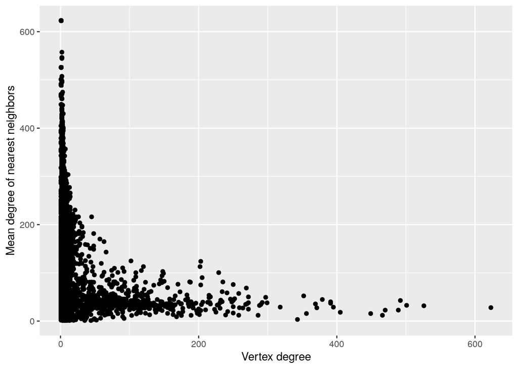

```r
drake::readd(enron_graph_characteristic_plot)
```

## Zadanie 12

Zastosowano dwie metody przełączania krawędzi, które są dostępne w pakiecie *igraph*:

- *each_edge* – rozpatruje każdą krawędź i przełącza jej końce z określonym prawdopodobieństwem (ja ustawiłem wartość p-stwa na 0.9). Metoda nie zachowuje stopni wierzchołków
- *keepin_degseq* – wykonuje iteracje w trakcie których wykonywana jest próba przełączenia krawędzi w taki sposób, żeby rozkłąd stopni wierzchołków się nie zmienił

### Ze zmianą rozkładu stopni wierzchołków

Zależność nadal jest malejąca. Jednak warto zwrócić uwagę jak bardzo zmienił się rozkład stopni wierzchołków.

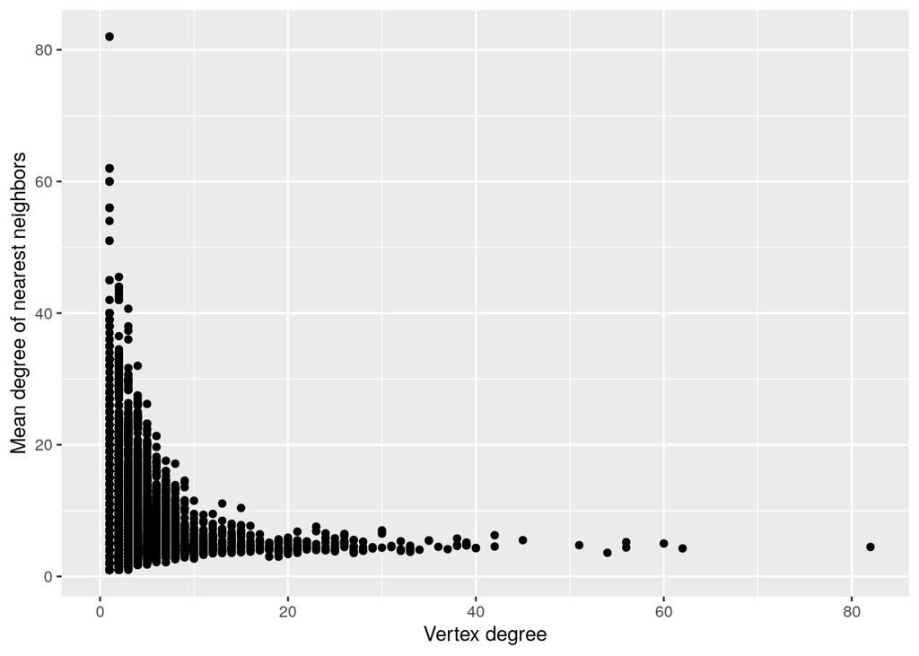

### Bez zmiany rozkładu stopni wierzchołków

Mimo dosyć dużej ilości iteracji (10 * $|V|$) nie widać znaczących zmian na wykresie.

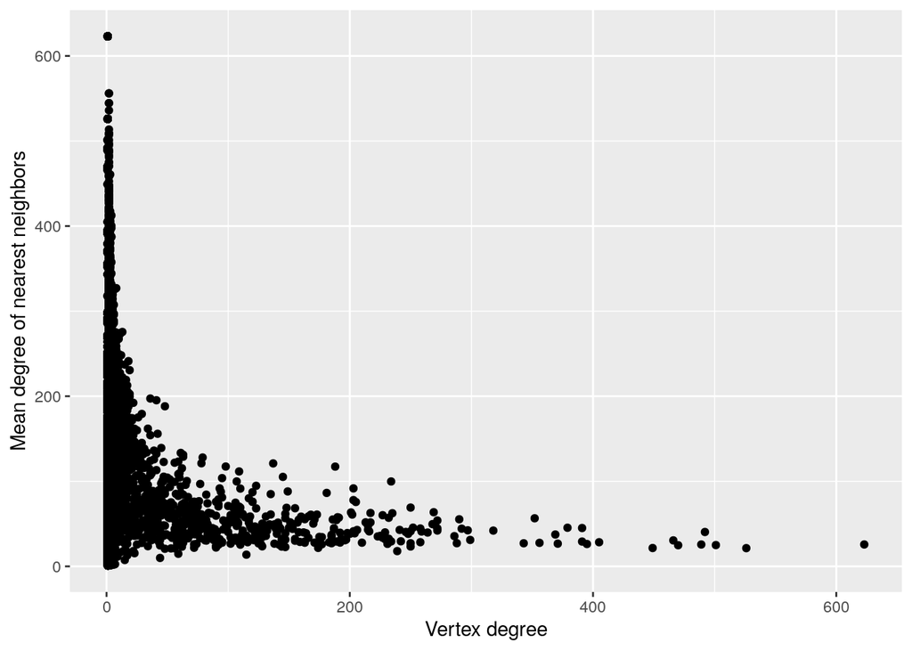

## Zadanie 14

```r
enron_altered_degseq_kept <- drake::readd(enron_altered_degseq_kept)
enron_altered_each_edge <- drake::readd(enron_altered_each_edge)

igraph::assortativity_degree(enron)
```

```
## [1] -0.106687
```

```r
igraph::assortativity_degree(enron_altered_each_edge)
```

```
## [1] -0.006705095
```

```r
igraph::assortativity_degree(enron_altered_degseq_kept)
```

```
## [1] -0.03131284
```

## Zadanie 16

Lepszą miarą jest *Wydajność*, ponieważ w przypadku sieci niespójnych *Średnia odległość* będzie dawała wartości nieskończone. Dodatkowo odwrotność *Wydajności* można interpretować jako średnią odległość międzywęzłową.

## Zadanie 17 i 18

```r
graphs <- list(
  list(graph = enron, name = "enron"),
  list(graph = UKfaculty, name ="Friendship network at a UK university"),
  list(graph = USairports, name ="Network of passenger flights between airports in the US")
)

df <- lapply(graphs, function(graph_conf) summarise_graph(graph_conf$graph, graph_conf$name)) %>%
  do.call(rbind, .)

knitr::kable(df)
```

| name | is_directed | vertex_count | edge_count | mean_degree | alpha | mean_distance | correlation |
| --- | --- | --- | --- | --- | --- | --- | --- |
| enron | TRUE | 32430 | 54397 | 3.35473327166204 | 4.49340079479382 | 3.76927675013719 | -0.106687034977619 |
| Friendship network at a UK university | TRUE | 81 | 817 | 20.1728395061728 | 1.46790744966915 | 2.51109375 | 0.0380520067410572 |
| Network of passenger flights between airports in the US | TRUE | 755 | 23473 | 62.1801324503311 | 1.37171796384723 | 3.52742994050263 | -0.0552463363041151 |

## Zadanie 19

### Zwycięzcy nagrody nobla

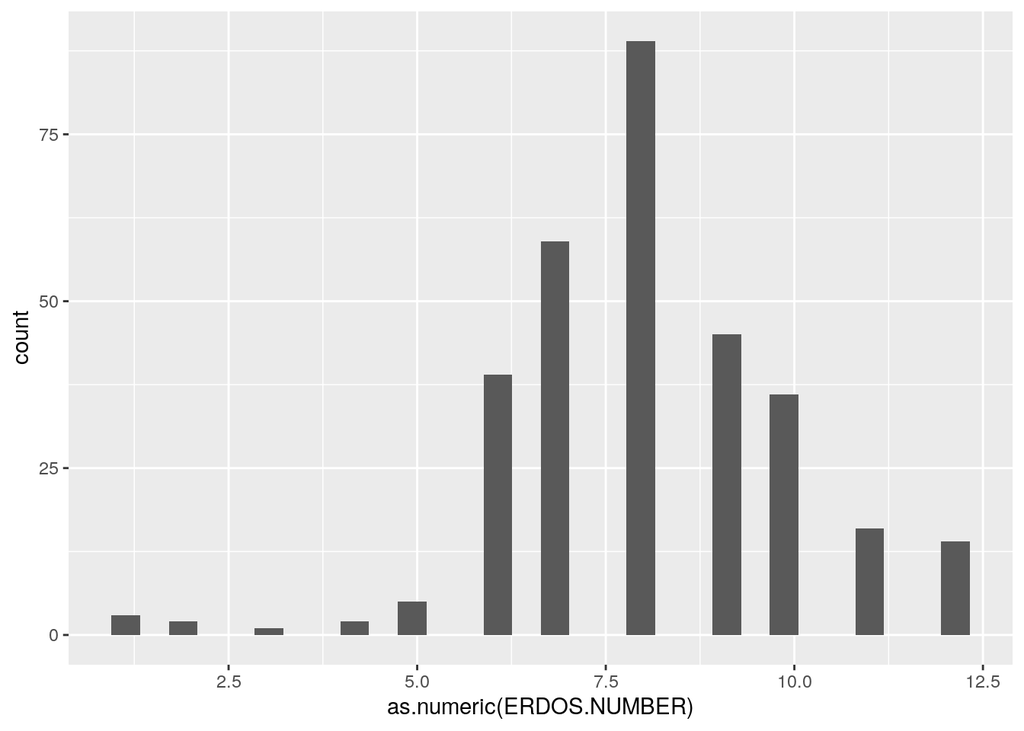

```r
drake::readd(nobel_prize_winners_erdos_number_histogram)
```

### Zwycięzcy medalu fieldsa

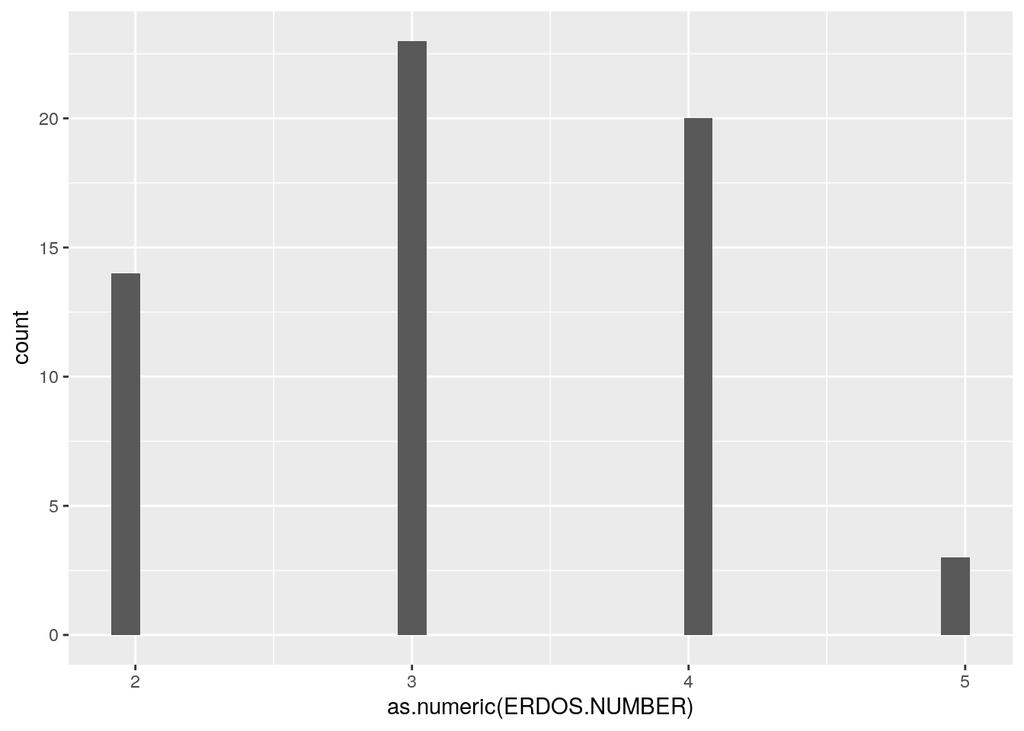

```r
drake::readd(field_medal_winners_erdos_number_histogram)
```

## Zadanie 21

```r
knitr::kable(drake::readd(actors_bacon_number_data))
```

| actor | bacon_number |
| --- | --- |
| Robert De Niro | 1 |
| Michał Żebrowski | 3 |
| Nikodem Rozbicki | 4 |

## Projekt

Wszystkie zaimplementowane miary zostały porównane z ich odpowiednikami z biblioteki `igraph` na następującym grafie:

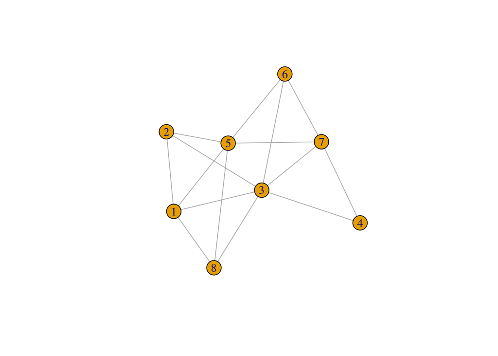

```r
test_graph <- drake::readd(example_graph_project4)
plot(test_graph)
```

### Średni stopień najbliższego węzła

```r
mean_nearest_vertex_degree(test_graph)
```

```
## [1] 4.133333
```

### Wykładnik w sieciach potęgowych

```r
sample_vertex_degrees <- poweRlaw::rpldis(1e6, xmin = 100, alpha = -2.5)
network_exponent(sample_vertex_degrees, xmin = 100)
```

```
## $alpha
## [1] -2.43646
##
## $sigma
## [1] -0.00343646
```

### Współczynnik korelacji

```r
network_correlation(test_graph)
```

```
## [1] -0.5835777
```

```r
igraph::assortativity_degree(test_graph)
```

```
## [1] -0.5835777
```

### Współczynniki Gronowania

#### Wersja 1

```r
clustering_coefficient_1(test_graph)
```

```
## [1] 0.5916667
```

#### Wersja 2

```r
clustering_coefficient_2(test_graph)
```

```
## [1] 0.4468085
```

```r
igraph::transitivity(test_graph)
```

```
## [1] 0.4468085
```

### Średnia odległość

```r
mean_distance(test_graph)
```

```
## [1] 1.464286
```

```r
igraph::mean_distance(test_graph)
```

```
## [1] 1.464286
```

### Wydajność

```r
efficiency(test_graph)
```

```
## [1] 0.7678571
```

```r
brainGraph::efficiency(test_graph, "global")
```

```
## [1] 0.7678571
```

### Pośrednictwo węzłowe

```r
node_betweenness(test_graph)
```

```
## [1] 0.02539683 0.00952381 0.32539683 0.00000000 0.15873016 0.00952381 0.08095238
## [8] 0.00952381
```

**Uwaga:** Implementacja tej miary w igraphie nie zawiera czynnika: $\frac{2}{(N - 1)(N - 2)}$. Źródło: https://igraph.org/r/doc/betweenness.html

```r
vertex_count <- vcount(test_graph)
2 * igraph::betweenness(test_graph) / ((vertex_count - 1) * (vertex_count - 2))
```

```
## [1] 0.02539683 0.00952381 0.32539683 0.00000000 0.15873016 0.00952381 0.08095238
## [8] 0.00952381
```